# Chill Portions and yield using actual data

Katja Schiffers<sup>a</sup>, Cory Whitney<sup>a</sup>, Eduardo Fernandez<sup>a</sup> and Eike Luedeling<sup>a</sup> <sup>a</sup>INRES-Horticultural Sciences, University of Bonn, Auf dem Huegel 6, 53121 Bonn, Germany

## Yield and chill data

In this file we applied the procedure for estimating yield as a function of chill accumulation. We used data provided by the experimental orchard of the School of Agronomy at the Pontificia Universidad Catolica de Valparaiso. The data set contains yield records (in tons per hectare) for 8 seasons (2010 to 2017) in two sweet cherry cultivars (Lapins and Brooks).

| Year | Variety | Yield |
| --- | --- | --- |
| 2010 | Lapins | 16.387600 |
| 2011 | Lapins | 11.401600 |
| 2012 | Lapins | 1.599200 |
| 2013 | Lapins | 13.521200 |
| 2014 | Lapins | 21.648480 |
| 2015 | Lapins | 9.413200 |
| 2016 | Lapins | 24.974440 |
| 2017 | Lapins | 8.515682 |
| 2010 | Brooks | 6.412400 |
| 2011 | Brooks | 1.296000 |
| 2012 | Brooks | 1.032000 |
| 2013 | Brooks | 3.396800 |
| 2014 | Brooks | 6.872400 |
| 2015 | Brooks | 2.887160 |
| 2016 | Brooks | 9.217320 |
| 2017 | Brooks | 9.892581 |

Weather data was obtained from a previous project (chill models comparison) from a weather station placed in the orchard.

| YEARMODA | Weather_Station | Year | Month | Day | JDay | Tmin | Tmax |
| --- | --- | --- | --- | --- | --- | --- | --- |
| 20100101 | Quillota | 2010 | 1 | 1 | 1 | 6.2 | 31.0 |
| 20100102 | Quillota | 2010 | 1 | 2 | 2 | 7.6 | 29.4 |
| 20100103 | Quillota | 2010 | 1 | 3 | 3 | 12.2 | 23.2 |
| 20100104 | Quillota | 2010 | 1 | 4 | 4 | 8.0 | 24.0 |
| 20100105 | Quillota | 2010 | 1 | 5 | 5 | 8.0 | 26.5 |
| 20100106 | Quillota | 2010 | 1 | 6 | 6 | 9.0 | 27.0 |
| 20100107 | Quillota | 2010 | 1 | 7 | 7 | 8.5 | 24.0 |
| 20100108 | Quillota | 2010 | 1 | 8 | 8 | 7.0 | 28.0 |
| 20100109 | Quillota | 2010 | 1 | 9 | 9 | 8.0 | 28.0 |
| 20100110 | Quillota | 2010 | 1 | 10 | 10 | 8.0 | 24.0 |

Using `tempResponse_daily_list()` in the `chillR()` package (Luedeling 2019) compute the chill accumulation for each season. In this example we defined the chilling season as the period between 1<sup>st</sup> of May and 31<sup>st</sup> of August.

| Season | End_year | Season_days | Data_days | Perc_complete | Chill_Portions |
| --- | --- | --- | --- | --- | --- |
| 2009/2010 | 2010 | 123 | 123 | 100 | 68.45256 |
| 2010/2011 | 2011 | 123 | 123 | 100 | 60.46397 |
| 2011/2012 | 2012 | 123 | 123 | 100 | 44.61716 |
| 2012/2013 | 2013 | 123 | 123 | 100 | 52.14200 |
| 2013/2014 | 2014 | 123 | 123 | 100 | 54.60832 |
| 2014/2015 | 2015 | 123 | 123 | 100 | 43.24068 |
| 2015/2016 | 2016 | 123 | 123 | 100 | 53.47477 |
| 2016/2017 | 2017 | 123 | 123 | 100 | 53.95999 |

Using `chillscatter()` create a Chill Portions (x) and yield (y) scatter plot with associated and estimated densities with loess smooth linear fits density curves. Plot made with the `scatter.hist()` function in the `plyr()` package (Wickham 2019). The following scatter plots show the outputs for Lapins (left) and Brooks (right) varieties.

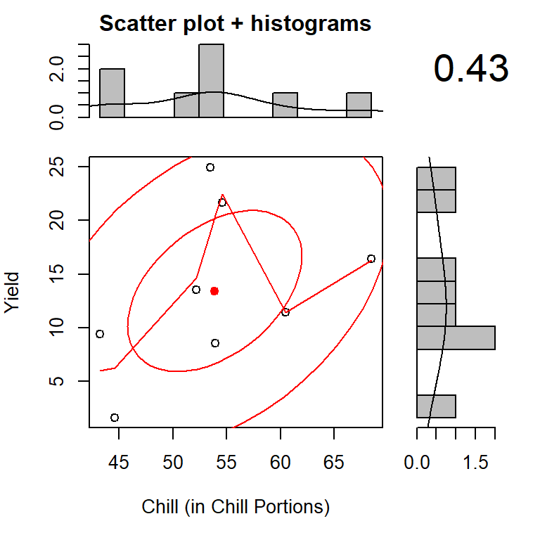

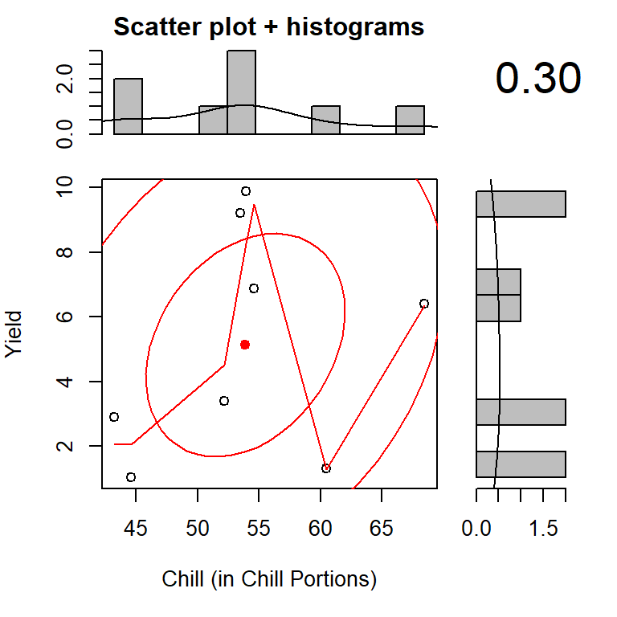

Use `chillkernel()` or another type of graphical representation of the same relationship. `chillkernel()` performs a two-dimensional kernel density estimation for yield and chill using the `kde2d()` function in the `MASS()` package (Ripley 2019). The function produces a matrix of the estimated density (z) of yield (y) and chill (x). As the density function restricts the shape of the kernel to a bivariate normal kernel, it looks slightly different compared to the scatter plot estimates above.

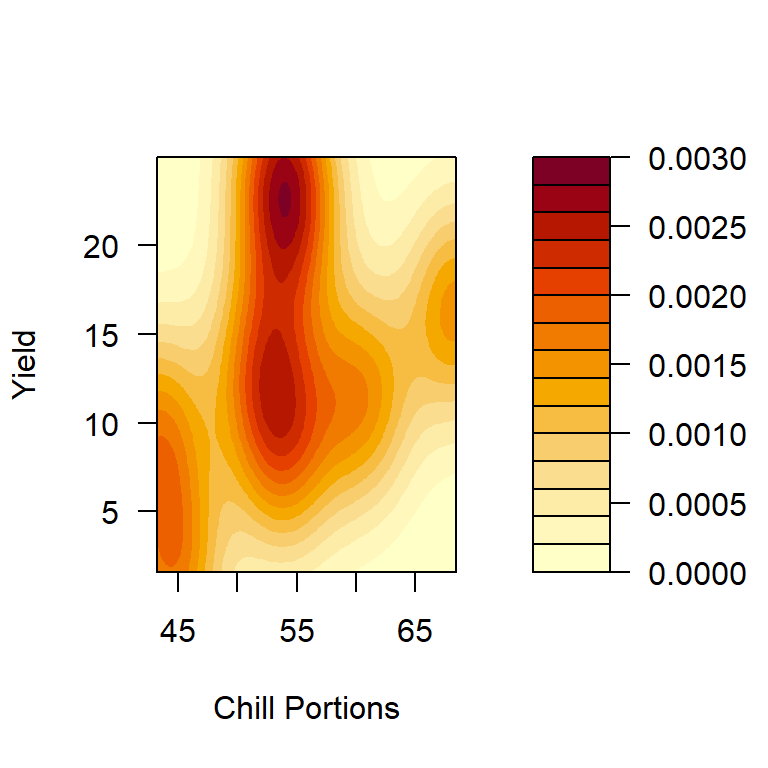

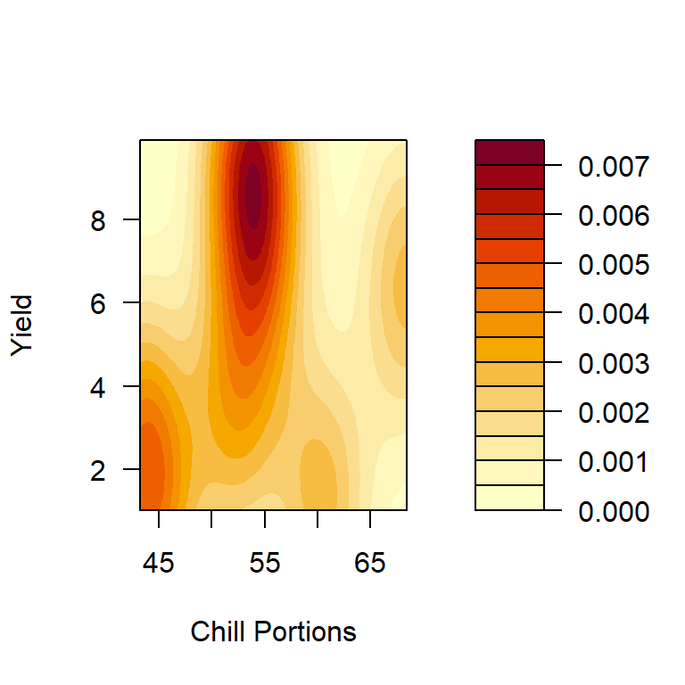

`chillkernel()` shows a density surface plot of Chill Portions (x) and yield (y). The legend shows the value for the estimated density (z). The plot is made with the `filled.contour()` function of the `graphics()` package (R Core Team 2019).

In `chillkernel()` the density (z) over the entire plot integrates to one, and therefore represents the relative probability of an observation (yield along y-axis) given a specific chill portion (along x-axis).

## Estimated yield given the expected chill

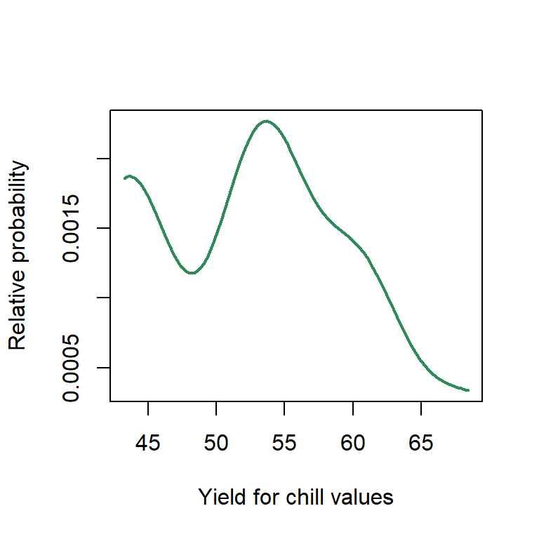

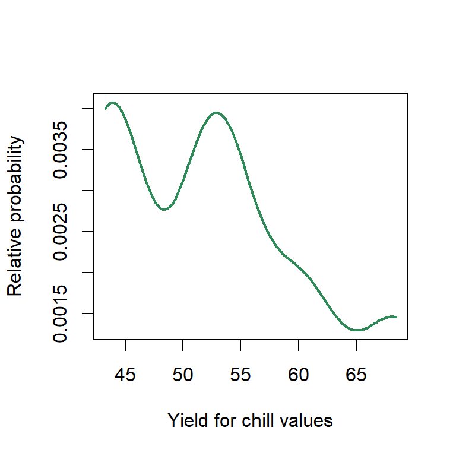

## Chill portion intervals

`chillviolin()` determines different possible chill portion intervals by calculating the optimal interval width for Chill Portions using the `IQR()` function in the `stats()` package, after the Freedman-Diaconis rule (IQR = interquartile range) (R Core Team 2019). `Optimal interval width for our sample = 2 * interquartile range for our sample / (total number of observations for the interquartile range for our sample)^(1/3)`

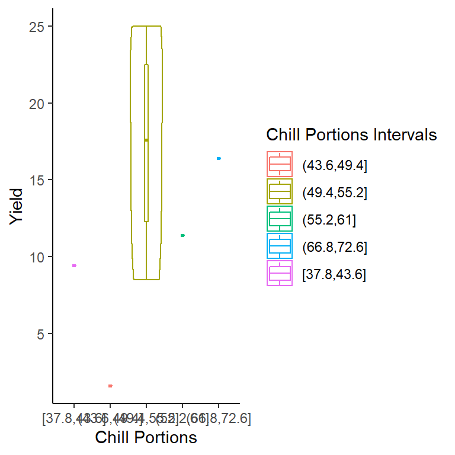

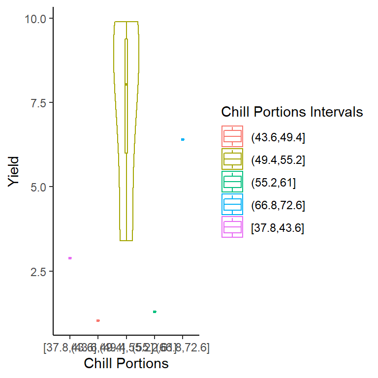

## Probability of yield given chill

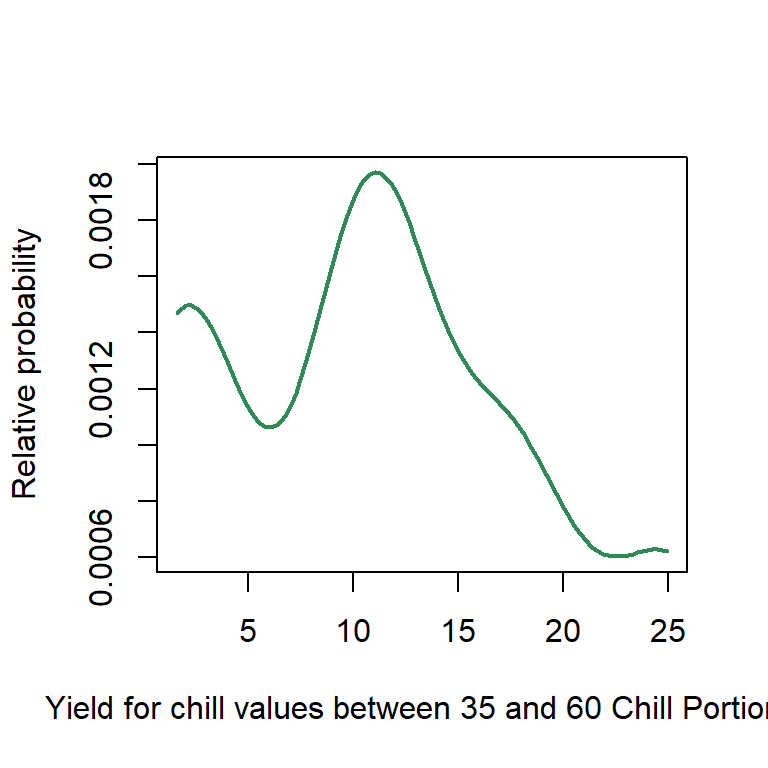

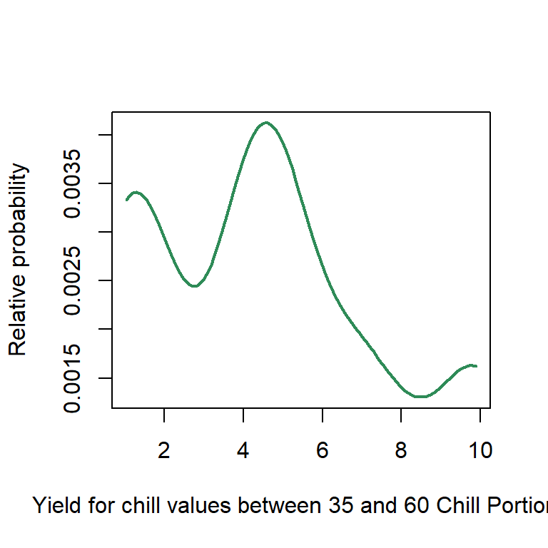

`chillkernelslicerange()` plots the probabilities (shown along the y-axis) for the expected yield (shown along the x-axis). As with `chillkernelslice()` the probability values shown are relative, not absolute measures. They are the result of cuts through the density kernel `chillkernel()`, which integrates to 1.

# Section

The functions here closely follow chillR (Luedeling 2019) and decisionSupport (Luedeling, Goehring, and Schiffers 2019).

## References

Luedeling, Eike. 2019. *ChillR: Statistical Methods for Phenology Analysis in Temperate Fruit Trees*. https://CRAN.R-project.org/package=chillR.

Luedeling, Eike, Lutz Goehring, and Katja Schiffers. 2019. *DecisionSupport: Quantitative Support of Decision Making Under Uncertainty*. https://CRAN.R-project.org/package=decisionSupport.

R Core Team. 2019. *R: A Language and Environment for Statistical Computing*. Vienna, Austria: R Foundation for Statistical Computing. https://www.R-project.org/.

Ripley, Brian. 2019. *MASS: Support Functions and Datasets for Venables and Ripley’s Mass*. https://CRAN.R-project.org/package=MASS.

Wickham, Hadley. 2019. *Plyr: Tools for Splitting, Applying and Combining Data*. https://CRAN.R-project.org/package=plyr.

Wickham, Hadley, Winston Chang, Lionel Henry, Thomas Lin Pedersen, Kohske Takahashi, Claus Wilke, Kara Woo, and Hiroaki Yutani. 2019. *Ggplot2: Create Elegant Data Visualisations Using the Grammar of Graphics*. https://CRAN.R-project.org/package=ggplot2.